# Abalone data set, Basic DL

Rick Scavetta

# Examples

## Part 1: Abalone Dataset

The UCI Abalone data-set is a small and easy starting point since it can be used for predicting age as either a categorical or continuous variable.

In the data files you’ll find the following variables:

| Variable | Type | Unit | Description |
| --- | --- | --- | --- |
| sex | nominal | – | M, F, and I (infant) |
| length | continuous | mm | Longest shell measurement |
| diameter | continuous | mm | perpendicular to length |
| height | continuous | mm | with meat in shell |
| whole_weight | continuous | grams | whole abalone |
| shucked_weight | continuous | grams | weight of meat |
| viscera_weight | continuous | grams | gut weight (after bleeding) |
| shell_weight | continuous | grams | after being dried |

In the labels file you’ll find the following variable:

| Variable | Type | Unit | Description |
| --- | --- | --- | --- |
| rings | integer | – | +1.5 gives the age in years |

The number of rings, variable `rings`, is the value to predict as either a continuous value or as a classification problem.

### Obtain data & Prepare data:

This data set is also available in the `AppliedPredictiveModeling` package.

```r
abalone_data <- read.csv("data/Complete/abalone_data.csv")
abalone_labels <- read.csv("data/Complete/abalone_labels_cont.csv")

glimpse(abalone_data)
```

```
## Observations: 4,177
## Variables: 8
## $ Sex            <int> 2, 2, 0, 2, 1, 1, 0, 0, 2, 0, 0, 2, 2, 0, 0, 2, 1…
## $ Length         <dbl> 0.455, 0.350, 0.530, 0.440, 0.330, 0.425, 0.530, …
## $ Diameter       <dbl> 0.365, 0.265, 0.420, 0.365, 0.255, 0.300, 0.415, …
## $ Height         <dbl> 0.095, 0.090, 0.135, 0.125, 0.080, 0.095, 0.150, …
## $ Whole_weight   <dbl> 0.5140, 0.2255, 0.6770, 0.5160, 0.2050, 0.3515, 0…
## $ Shucked_weight <dbl> 0.2245, 0.0995, 0.2565, 0.2155, 0.0895, 0.1410, 0…
## $ Viscera_weight <dbl> 0.1010, 0.0485, 0.1415, 0.1140, 0.0395, 0.0775, 0…
## $ Shell_weight   <dbl> 0.150, 0.070, 0.210, 0.155, 0.055, 0.120, 0.330, …
```

### Examine data:

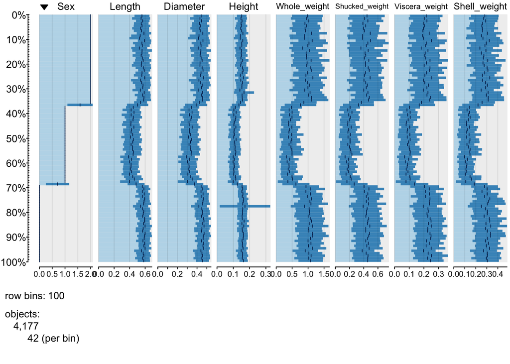

```r
tabplot::tableplot(abalone_data)
```

### plot the data anew:

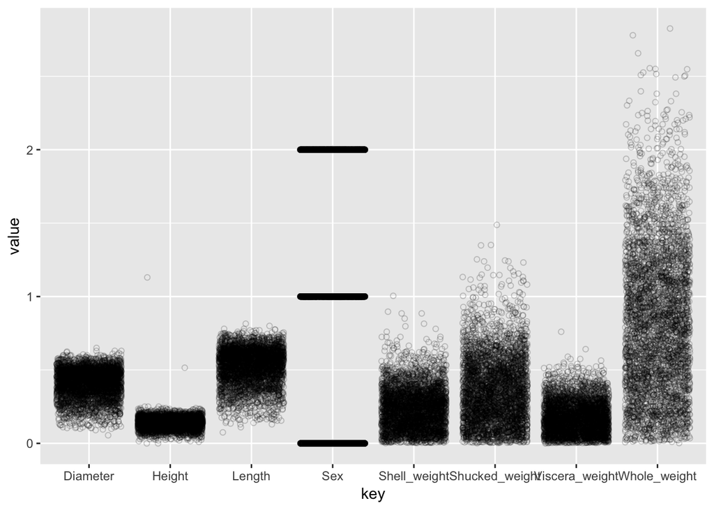

```r
abalone_data %>%
  gather() %>%
  ggplot(aes(key, value)) +
  geom_jitter(shape = 1, alpha = 0.2)
```

Transformation

```r
abalone_data %>%
  mutate_all(scale) -> abalone_data
```

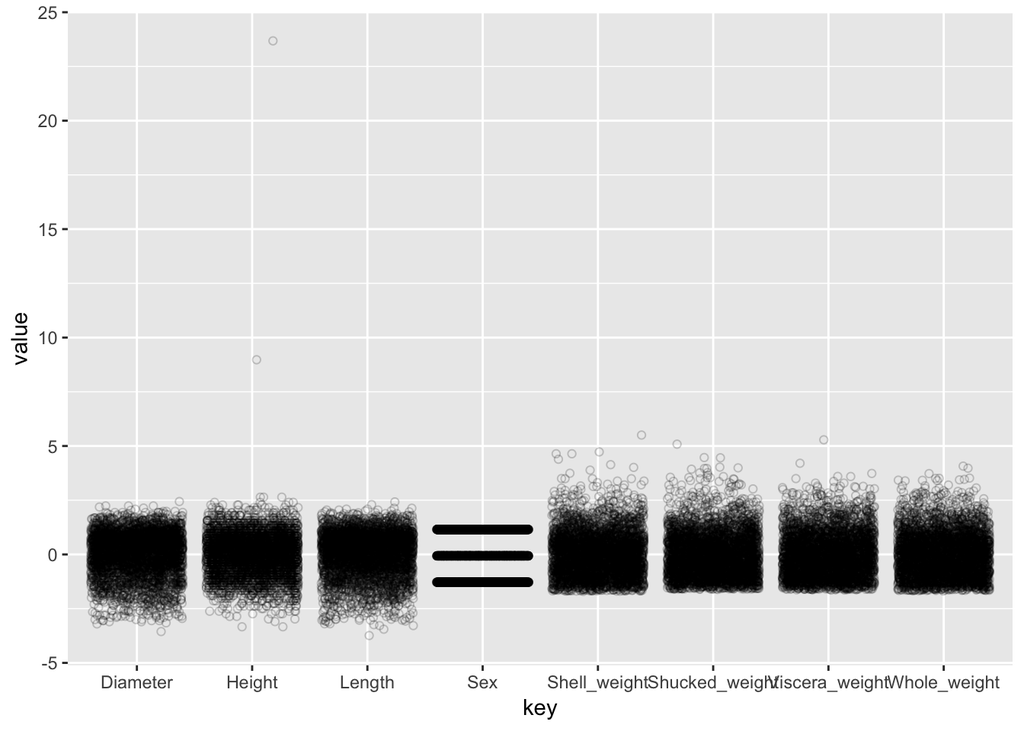

```r
abalone_data %>%
  gather() %>%
  ggplot(aes(key, value)) +
  geom_jitter(shape = 1, alpha = 0.2)
```

```r
# there are two extreme values, that may cause a problem

rem_index <- which(abalone_data$Height > 5)


abalone_data %>%
  slice(-rem_index) -> abalone_data

abalone_labels %>%
  slice(-rem_index) -> abalone_labels
```

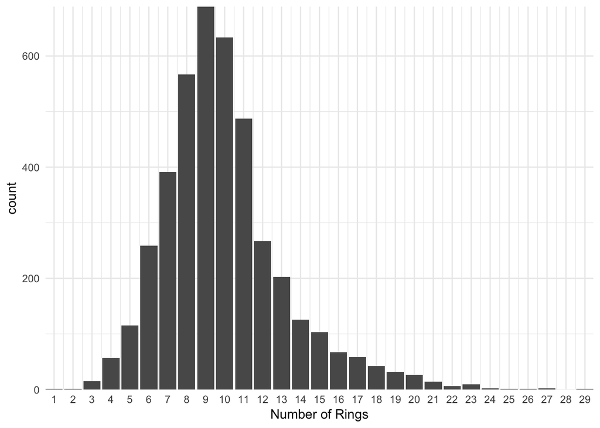

```r
ggplot(abalone_labels, aes(Rings)) +
  geom_bar() +
  scale_x_continuous("Number of Rings", breaks = 1:29) +
  coord_cartesian(expand = 0) +
  theme_minimal()
```

All values from 1-27 & 29 are present. The training and test set should contain at least one representative of each group.

## Part 2: Training and Test sets

```r
train_n <- round(0.8*nrow(abalone_data))
test_n <- round(0.2*nrow(abalone_data))
```

number of training instances n = 3340.

number of test instances n = 835.

### Split up training and test

```r
# Convert to a matrix:
abalone_data <- as.matrix(abalone_data)

set.seed(136)
train_index <- sample(seq_len(nrow(abalone_data)), train_n)

train_data <- unname(abalone_data[train_index,])
train_labels <- abalone_labels[train_index,]

test_data <- unname(abalone_data[-train_index,])
test_labels <- abalone_labels[-train_index,]
```

```r
str(train_data)
```

```
##  num [1:3340, 1:8] 1.1518 1.1518 1.1518 -1.2805 -0.0643 ...
```

```r
str(test_data)
```

```
##  num [1:835, 1:8] -1.28 1.15 -1.28 1.15 -1.28 ...
```

## Labels

```r
table(train_labels)
```

```
## train_labels
##   1   3   4   5   6   7   8   9  10  11  12  13  14  15  16  17  18  19
##   1  11  47  91 207 307 446 546 510 389 219 163 103  88  52  48  34  28
##  20  21  22  23  24  25  26  27  29
##  21  12   4   7   2   1   1   1   1
```

```r
table(test_labels)
```

```
## test_labels
##   2   3   4   5   6   7   8   9  10  11  12  13  14  15  16  17  18  19
##   1   4  10  24  52  84 121 143 123  98  48  40  23  15  15  10   8   4
##  20  21  22  23  27
##   5   2   2   2   1
```

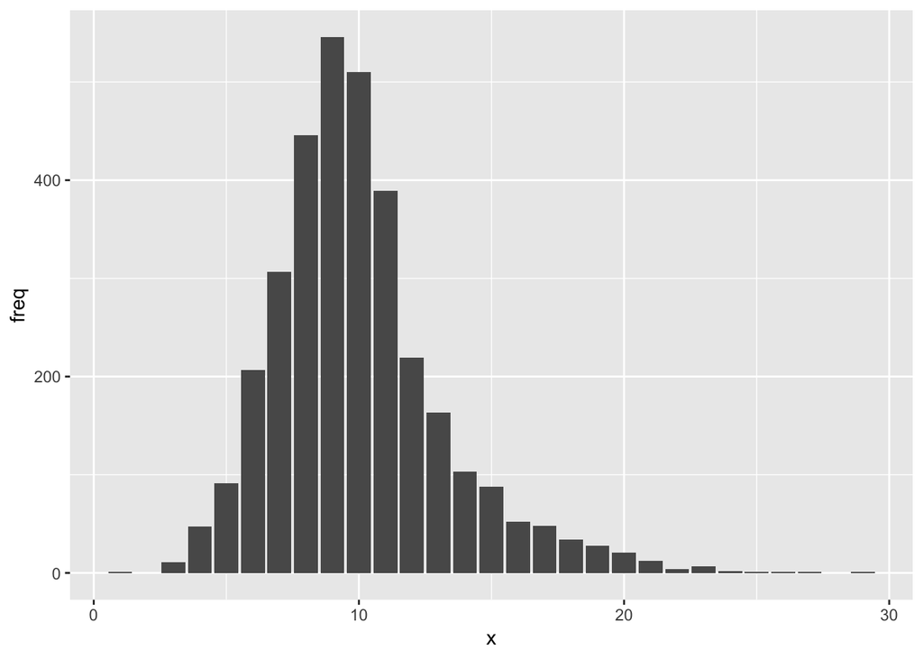

```r
# Note plyr not dplyr here. I'm just using a shortcut

train_labels %>%
  plyr::count() %>%
  ggplot(aes(x, freq)) +
  geom_col()
```

The distribution of the test and training set should be roughly equivalent, so let’s have a look.

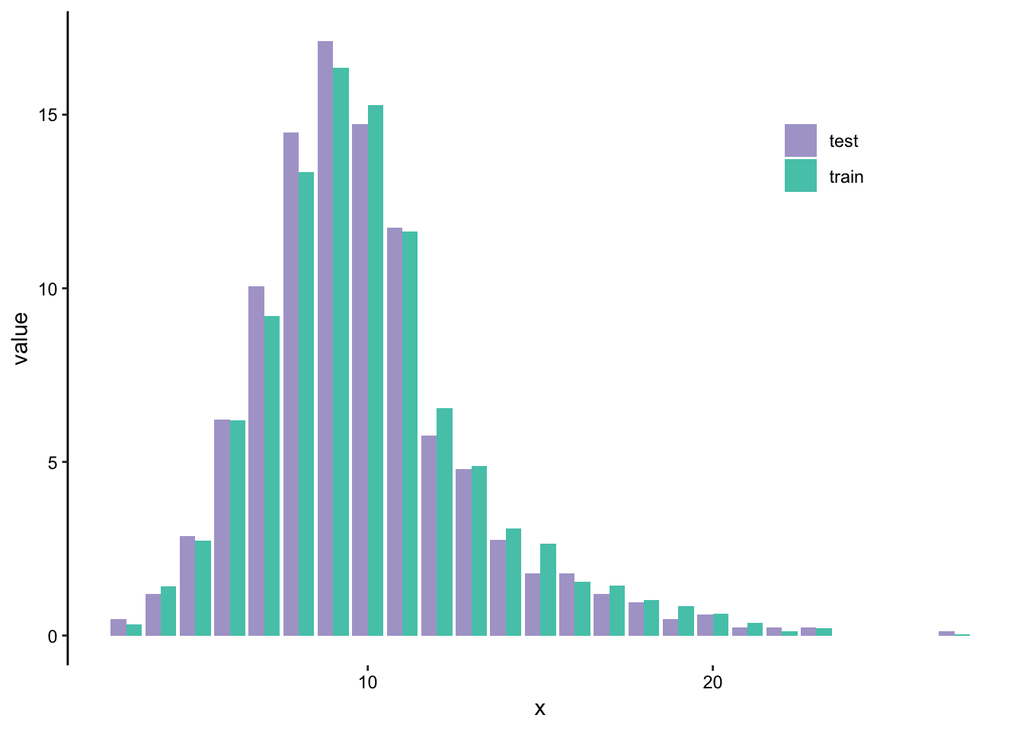

```r
data.frame(x = train_labels) %>%
  group_by(x) %>%
  summarise(train_freq = 100*n()/length(train_labels)) -> train_labels_df

data.frame(x  = test_labels) %>%
  group_by(x) %>%
  summarise(test_freq = 100 * n()/length(test_labels)) %>%
  inner_join(train_labels_df, by="x") %>%
  gather(key, value, -x) %>%
  ggplot(aes(x, value, fill = key)) +
  geom_col(position = "dodge") +
  # scale_y_continuous("Percentage", limits = c(0,20), expand = c(0,0)) +
  # scale_x_continuous("Label", breaks = 0:45, expand = c(0,0)) +
  scale_fill_manual("", labels = c("test","train"), values = c("#AEA5D0", "#54C8B7")) +
  theme_classic() +
  theme(legend.position = c(0.8, 0.8),
        axis.line.x = element_blank(),
        axis.text = element_text(colour = "black"))
```

Make the format match the output we expect to get from softmax so that we can make a direct comparison.

```r
train_labels_vec <- to_categorical(train_labels)
test_labels_vec <- to_categorical(test_labels)
```

```r
colSums(test_labels_vec)
```

```
##  [1]   0   0   1   4  10  24  52  84 121 143 123  98  48  40  23  15  15
## [18]  10   8   4   5   2   2   2   0   0   0   1
```

```r
colSums(train_labels_vec)
```

```
##  [1]   0   1   0  11  47  91 207 307 446 546 510 389 219 163 103  88  52
## [18]  48  34  28  21  12   4   7   2   1   1   1   0   1
```

```r
str(train_labels_vec)
```

```
##  num [1:3340, 1:30] 0 0 0 0 0 0 0 0 0 0 ...
```

```r
str(test_labels_vec)
```

```
##  num [1:835, 1:28] 0 0 0 0 0 0 0 0 0 0 ...
```

## Part 3: Regression

### Training

```r
network <- keras_model_sequential() %>%
  layer_dense(units = 32, activation = "relu", input_shape = 8) %>%
  layer_dense(units = 32, activation = "relu") %>%
  layer_dense(units = 1)
```

```r
network %>% compile(
  optimizer = "rmsprop",
  loss = "mse",
  metrics = "mae"
)
```

```r
history <- network %>% fit(
  train_data,
  train_labels,
  epochs = 50,
  batch_size = 64
  )
```

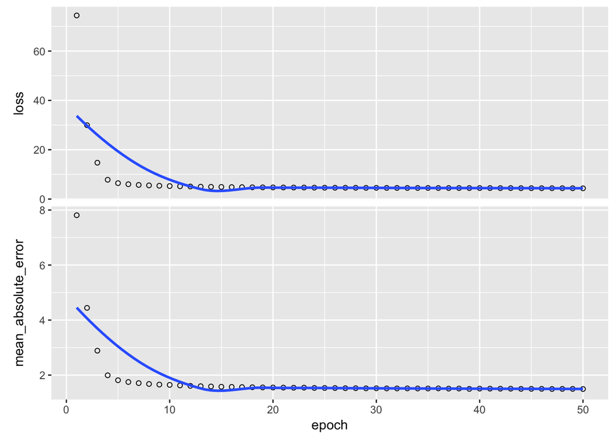

```r
plot(history)
```

## Model Evaluation:

```r
result <- network %>%
  evaluate(test_data, test_labels)
```

### Results:

```r
MAE <- result$mean_absolute_error
```

```r
result
```

```
## $loss
## [1] 4.079245
##
## $mean_absolute_error
## [1] 1.455425
```

The MAE is 1.4554248.

To get the actual predictions we can use the `predict()` function:

```r
network %>%
  predict(test_data) %>%
  head()
```

```
##           [,1]
## [1,] 12.309318
## [2,] 11.408781
## [3,] 11.643259
## [4,] 12.133617
## [5,]  9.935297
## [6,]  8.800653
```

[output not shown]

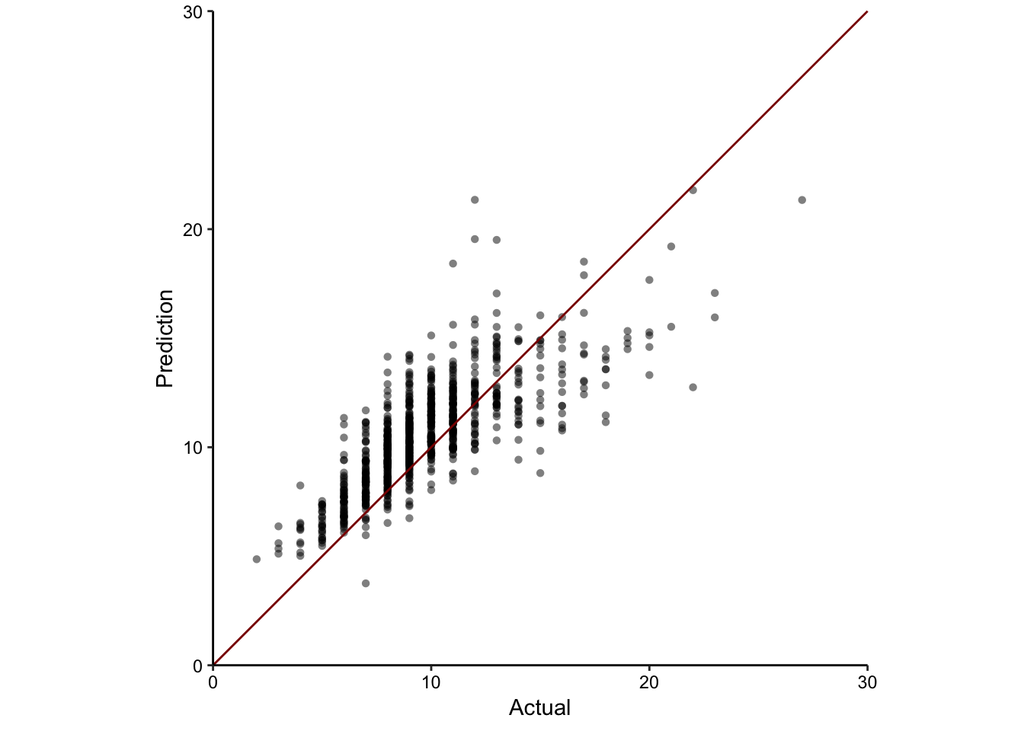